# STAT 184 Final Project

Tyler Applegate

12 / 13 / 2020

## Research Question

Within this project report, we will be exploring the numerous factors that are involved in pricing a used car. The main focus of this project is to determine what the most influential factors are in pricing a used car.

**Guiding Question:** What are the most influential aspects of a used car that impact the value of the car at resale?

## Load Packages

```r
library(tidyverse)
library(DataComputing)
library(party)
library(rpart)
library(rpart.plot)
library(rattle)
```

## Data Access

**Primary Data Source**

```r
PrimaryCars <- read.csv("/Users/tylerapplegate/Desktop/vehicles_updated.csv")
```

[Data Link](https://www.kaggle.com/austinreese/craigslist-carstrucks-data)

*Data Inspection*

```r
head(PrimaryCars)
```

|  | region | X | price | year | manufacturer | model | condition | cylinders | fuel | odometer | title_status | transmission | X.1 | drive | size | type | paint_color | state |
| --- | --- | --- | --- | --- | --- | --- | --- | --- | --- | --- | --- | --- | --- | --- | --- | --- | --- | --- |
| 1 | duluth / superior | NA | 6995 | 2000 | gmc | new sierra 1500 | excellent | 8 cylinders | gas | 167783 | clean | automatic | NA | 4wd |  |  | red | mn |
| 2 | duluth / superior | NA | 8750 | 2013 | hyundai | sonata | excellent | 4 cylinders | gas | 90821 | clean | automatic | NA | fwd |  |  | grey | mn |
| 3 | new haven | NA | 10900 | 2013 | toyota | prius | good | 4 cylinders | hybrid | 92800 | clean | automatic | NA | fwd |  |  | blue | ct |
| 4 | albuquerque | NA | 12500 | 2003 | mitsubishi | lancer | good | 4 cylinders | gas | NA | clean | manual | NA | 4wd | mid-size | sedan | grey | nm |
| 5 | duluth / superior | NA | 16995 | 2007 | gmc | sierra classic 2500hd | good | 8 cylinders | diesel | 254217 | clean | automatic | NA | 4wd | full-size | truck | white | mn |
| 6 | duluth / superior | NA | 13995 | 2012 | ford | f-150 | good | 6 cylinders | gas | 188406 | clean | automatic | NA | 4wd | full-size | truck | grey | mn |

```r
str(PrimaryCars)
```

```
'data.frame':   4854 obs. of  18 variables:
 $ region      : Factor w/ 28 levels "","albany","albuquerque",..: 7 7 15 3 7 7 7 7 7 7 ...
 $ X           : logi  NA NA NA NA NA NA ...
 $ price       : num  6995 8750 10900 12500 16995 ...
 $ year        : int  2000 2013 2013 2003 2007 2012 2010 2011 2014 2004 ...
 $ manufacturer: Factor w/ 36 levels "","acura","audi",..: 13 15 34 26 13 12 7 7 12 29 ...
 $ model       : Factor w/ 2045 levels "",".","/ jag kit",..: 1320 1697 1422 1154 1632 732 657 1863 711 61 ...
 $ condition   : Factor w/ 7 levels "","excellent",..: 2 2 4 4 4 4 4 4 4 4 ...
 $ cylinders   : Factor w/ 9 levels "","10 cylinders",..: 8 5 5 5 8 7 5 7 7 7 ...
 $ fuel        : Factor w/ 6 levels "","diesel","electric",..: 4 4 5 4 2 4 4 4 4 2 ...
 $ odometer    : int  167783 90821 92800 NA 254217 188406 108124 178054 170259 309621 ...
 $ title_status: Factor w/ 7 levels "","clean","lien",..: 2 2 2 2 2 2 2 2 2 2 ...
 $ transmission: Factor w/ 4 levels "","automatic",..: 2 2 2 3 2 2 2 2 2 2 ...
 $ X.1         : logi  NA NA NA NA NA NA ...
 $ drive       : Factor w/ 4 levels "","4wd","fwd",..: 2 3 3 2 2 2 2 2 2 2 ...
 $ size        : Factor w/ 5 levels "","compact","full-size",..: 1 1 1 4 3 3 3 3 3 3 ...
 $ type        : Factor w/ 14 levels "","bus","convertible",..: 1 1 1 10 12 12 11 11 11 12 ...
 $ paint_color : Factor w/ 13 levels "","black","blue",..: 10 7 3 7 12 7 7 12 12 5 ...
 $ state       : Factor w/ 14 levels ""," Contact Me -  show contact info",..: 8 8 4 10 8 8 8 8 8 8 ...
```

**Secondary Data Source:**

```r
SecondaryCars <- read.csv("/Users/tylerapplegate/Desktop/USA_cars_datasets.csv")
```

[Data Link](https://www.kaggle.com/doaaalsenani/usa-cers-dataset)

*Data Inspection*

```r
head(SecondaryCars)
```

|  | X | price | brand | model | year | title_status | mileage | color | vin | lot | state | country | condition |
| --- | --- | --- | --- | --- | --- | --- | --- | --- | --- | --- | --- | --- | --- |
| 1 | 0 | 6300 | toyota | cruiser | 2008 | clean vehicle | 274117 | black | jtezu11f88k007763 | 159348797 | new jersey | usa | 10 days left |
| 2 | 1 | 2899 | ford | se | 2011 | clean vehicle | 190552 | silver | 2fmdk3gc4bbb02217 | 166951262 | tennessee | usa | 6 days left |
| 3 | 2 | 5350 | dodge | mpv | 2018 | clean vehicle | 39590 | silver | 3c4pdcgg5jt346413 | 167655728 | georgia | usa | 2 days left |
| 4 | 3 | 25000 | ford | door | 2014 | clean vehicle | 64146 | blue | 1ftfw1et4efc23745 | 167753855 | virginia | usa | 22 hours left |
| 5 | 4 | 27700 | chevrolet | 1500 | 2018 | clean vehicle | 6654 | red | 3gcpcrec2jg473991 | 167763266 | florida | usa | 22 hours left |
| 6 | 5 | 5700 | dodge | mpv | 2018 | clean vehicle | 45561 | white | 2c4rdgeg9jr237989 | 167655771 | texas | usa | 2 days left |

```r
str(SecondaryCars)
```

```
'data.frame':   2499 obs. of  13 variables:
 $ X           : int  0 1 2 3 4 5 6 7 8 9 ...
 $ price       : int  6300 2899 5350 25000 27700 5700 7300 13350 14600 5250 ...
 $ brand       : Factor w/ 28 levels "acura","audi",..: 28 9 8 9 6 8 6 10 6 9 ...
 $ model       : Factor w/ 127 levels "1500","2500",..: 26 93 76 33 1 76 87 33 72 76 ...
 $ year        : int  2008 2011 2018 2014 2018 2018 2010 2017 2018 2017 ...
 $ title_status: Factor w/ 2 levels "clean vehicle",..: 1 1 1 1 1 1 1 1 1 1 ...
 $ mileage     : num  274117 190552 39590 64146 6654 ...
 $ color       : Factor w/ 49 levels "beige","billet silver metallic clearcoat",..: 3 40 40 5 35 47 3 16 40 3 ...
 $ vin         : Factor w/ 2495 levels "  19uua96529a004646",..: 2393 1666 1886 968 2088 1650 1194 1239 1123 1706 ...
 $ lot         : int  159348797 166951262 167655728 167753855 167763266 167655771 167753872 167692494 167763267 167656121 ...
 $ state       : Factor w/ 44 levels "alabama","arizona",..: 25 36 8 40 7 37 8 4 7 37 ...
 $ country     : Factor w/ 2 levels " canada"," usa": 2 2 2 2 2 2 2 2 2 2 ...
 $ condition   : Factor w/ 47 levels "1 days left",..: 4 40 17 21 21 17 21 19 21 17 ...
```

## Data Wrangling

**General Data Wrangling -** These steps remove the unwanted attributes that contain numerous empty cells, and remove the remaining cases that still contain any empty cells / cells that contain inaccurate information.

```r
PrimaryCars <-
  PrimaryCars %>%
  select("region", "price", "year", "manufacturer", "fuel", "odometer", "transmission", "drive", "paint_color")
```

```r
PrimaryCars <-
  PrimaryCars %>%
  filter(region != "" | NA, price != "" | NA, year != "" | NA, manufacturer != "" | NA, fuel != "" | NA, odometer != "" | NA, transmission != "" | NA, drive != "" | NA, paint_color != "" | NA, transmission != "other", fuel != "other")
```

**Regular Expression Locate and Replace Operation -** This data set treated the brand “Dodge” and “Ram” as two separate manufacturers, but I wanted to treat them as the same. So, this code replaces every “ram” brand with “dodge”.

```r
PrimaryCars <-
  PrimaryCars %>%
  mutate(manufacturer = gsub(pattern = "ram", replacement = "dodge", x = manufacturer))
```

**New Data Inspection**

```r
head(PrimaryCars)
```

|  | region | price | year | manufacturer | fuel | odometer | transmission | drive | paint_color |
| --- | --- | --- | --- | --- | --- | --- | --- | --- | --- |
| 1 | duluth / superior | 6995 | 2000 | gmc | gas | 167783 | automatic | 4wd | red |
| 2 | duluth / superior | 8750 | 2013 | hyundai | gas | 90821 | automatic | fwd | grey |
| 3 | new haven | 10900 | 2013 | toyota | hybrid | 92800 | automatic | fwd | blue |
| 4 | duluth / superior | 16995 | 2007 | gmc | diesel | 254217 | automatic | 4wd | white |
| 5 | duluth / superior | 13995 | 2012 | ford | gas | 188406 | automatic | 4wd | grey |
| 6 | duluth / superior | 7995 | 2010 | chevrolet | gas | 108124 | automatic | 4wd | grey |

```r
str(PrimaryCars)
```

```
'data.frame':   2351 obs. of  9 variables:
 $ region      : Factor w/ 28 levels "","albany","albuquerque",..: 7 7 15 7 7 7 7 7 7 7 ...
 $ price       : num  6995 8750 10900 16995 13995 ...
 $ year        : int  2000 2013 2013 2007 2012 2010 2011 2014 2004 2011 ...
 $ manufacturer: chr  "gmc" "hyundai" "toyota" "gmc" ...
 $ fuel        : Factor w/ 6 levels "","diesel","electric",..: 4 4 5 2 4 4 4 4 2 4 ...
 $ odometer    : int  167783 90821 92800 254217 188406 108124 178054 170259 309621 210865 ...
 $ transmission: Factor w/ 4 levels "","automatic",..: 2 2 2 2 2 2 2 2 2 2 ...
 $ drive       : Factor w/ 4 levels "","4wd","fwd",..: 2 3 3 2 2 2 2 2 2 2 ...
 $ paint_color : Factor w/ 13 levels "","black","blue",..: 10 7 3 12 7 7 12 12 5 11 ...
```

**Reduction / Transformation Functions -** This code was intended to wrangle the data in a way to see if a correlation exists between the manufacturer of the car and the average resale value of their cars.

```r
ManufacturerAverage <-
  PrimaryCars %>%
  group_by(manufacturer) %>%
  summarise(total = sum(price), count = n()) %>%
  mutate(average_price = total / count)
ManufacturerAverage
```

| manufacturer | total | count | average_price |
| --- | --- | --- | --- |
| acura | 271872 | 25 | 10874.880 |
| audi | 175823 | 21 | 8372.524 |
| bmw | 882768 | 67 | 13175.642 |
| buick | 367876 | 29 | 12685.379 |
| cadillac | 641866 | 30 | 21395.533 |
| chevrolet | 5777232 | 331 | 17453.873 |
| chrysler | 356581 | 40 | 8914.525 |
| dodge | 5279242 | 204 | 25878.637 |
| ferrari | 106899 | 1 | 106899.000 |
| fiat | 34495 | 4 | 8623.750 |

[output cut: 23 more lines]

**Spread / Gather Operation -** This wrangling will enable us to easily see the impact on the average resale price of a car based off the drive type of the vehicle and the manufacturer of the vehicle.

```r
DrivePrice <-
  PrimaryCars %>%
  group_by(manufacturer, drive) %>%
  summarise(total = sum(price), count = n()) %>%
  mutate(average_price = total / count)
DrivePrice
```

| manufacturer | drive | total | count | average_price |
| --- | --- | --- | --- | --- |
| acura | 4wd | 123414 | 9 | 13712.667 |
| acura | fwd | 148458 | 16 | 9278.625 |
| audi | 4wd | 136825 | 15 | 9121.667 |
| audi | fwd | 23998 | 3 | 7999.333 |
| audi | rwd | 15000 | 3 | 5000.000 |
| bmw | 4wd | 420695 | 29 | 14506.724 |
| bmw | fwd | 12500 | 1 | 12500.000 |
| bmw | rwd | 449573 | 37 | 12150.622 |
| buick | 4wd | 144371 | 8 | 18046.375 |
| buick | fwd | 202670 | 17 | 11921.765 |

[output cut: 77 more lines]

```r
DrivePrice2 <-
  DrivePrice %>%
  select("manufacturer", "drive", "average_price") %>%
  spread(key = drive, value = average_price)

DrivePrice2
```

| manufacturer | 4wd | fwd | rwd |
| --- | --- | --- | --- |
| acura | 13712.667 | 9278.625 | NA |
| audi | 9121.667 | 7999.333 | 5000.000 |
| bmw | 14506.724 | 12500.000 | 12150.622 |
| buick | 18046.375 | 11921.765 | 5208.750 |
| cadillac | 29630.400 | 9462.500 | 15626.111 |
| chevrolet | 22297.103 | 9489.460 | 15438.702 |
| chrysler | 11069.600 | 7457.821 | 13202.000 |
| dodge | 33439.941 | 10612.320 | 21979.229 |
| ferrari | NA | NA | 106899.000 |
| fiat | 12500.000 | 7331.667 | NA |

[output cut: 23 more lines]

**Machine Learning -** Within these code chunks I chose the most popular manufacturers (manufacturers with the most data for the model to utilize) alongside some other attributes that I picked in order to get an idea of what factors are most closely correlated to determining the price.

```r
PrimaryCars %>%
  group_by(manufacturer) %>%
  summarise(count = n()) %>%
  filter(count >= 99) %>%
  arrange(desc(count))
```

| manufacturer | count |
| --- | --- |
| ford | 412 |
| chevrolet | 331 |
| toyota | 244 |
| dodge | 204 |
| jeep | 146 |
| honda | 141 |
| nissan | 118 |

```r
RegressionCars <-
  PrimaryCars %>%
  filter(manufacturer == "ford" | manufacturer == "chevrolet" | manufacturer == "toyota" | manufacturer == "jeep" | manufacturer == "honda" | manufacturer == "nissan" | manufacturer == "dodge" | manufacturer == "gmc")
```

```r
regressMod <- lm(price ~ year + manufacturer + fuel + odometer + transmission + drive, data = RegressionCars)

regressMod$coefficients
```

```
       (Intercept)               year
     -1.574563e+06       8.021206e+02
 manufacturerdodge   manufacturerford
      2.928938e+03       1.281487e+03
   manufacturergmc  manufacturerhonda
      1.683642e+03      -2.482832e+02
  manufacturerjeep manufacturernissan
     -3.286839e+03      -2.780556e+03
manufacturertoyota       fuelelectric
      3.144419e+03      -1.154034e+04
           fuelgas         fuelhybrid
     -1.384434e+04      -1.560450e+04
          odometer transmissionmanual
     -2.951813e-02       1.865872e+03
          drivefwd           driverwd
     -1.383323e+04      -3.899858e+03
```

## Data Visualization

**Layered Graphics / Multiple Aesthetics and Geoms -** This stacked bar graph displays the average price per car by each manufacturer. The break down of proportion of each type of drive train can be seen as well. From this display, it can easily be seen that Lexus’ has the highest average resale value, and they are almost all rear wheel drive vehicles.

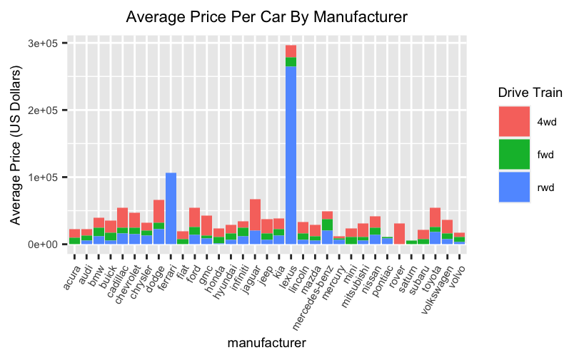

```r
DrivePrice %>%
  ggplot(aes(fill = drive, y = average_price, x = manufacturer)) +
  geom_bar(position = "stack", stat = "identity") +
  ylab("Average Price (US Dollars)") +
  theme(axis.text.x = element_text(angle = 60, hjust = 1), text = element_text(size = 7)) +
  labs(title = "Average Price Per Car By Manufacturer", fill = "Drive Train") +
  theme(plot.title = element_text(hjust = 0.5))
```

This faceted scatter plot illustrates the spread of prices across the years. Also included, are the four different engine types, and also the various drive trains. This does a good job at showing that four wheel drive vehicles seem to have a higher resale value compared to the other drive train options. It also seems like hybrid and electric cars do not retain as much resale value as diesel or gas vehicles. I also decided to filter out some cases in order to remove extreme cases that disrupted the display of the other data points.

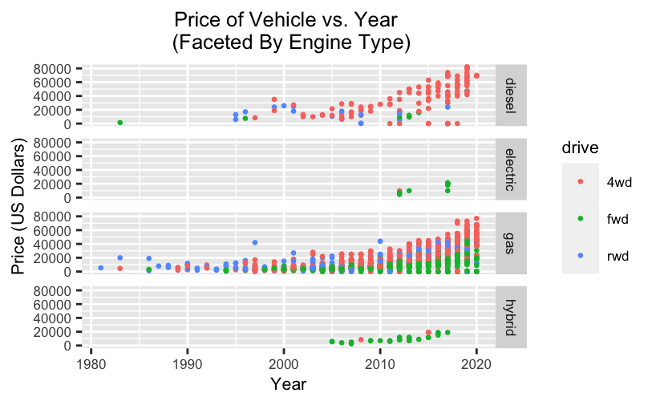

```r
PrimaryCars %>%
  filter(price <= 100000, year >= 1980) %>%
  ggplot(aes(x = year, y = price)) +
  geom_point(aes(colour = drive), size = 0.5) +
  ylab("Price (US Dollars)") +
  xlab("Year") +
  facet_grid(fuel ~ .) +
  labs(title = "Price of Vehicle vs. Year \n (Faceted By Engine Type)", fill = "Drive Train") +
  theme(plot.title = element_text(hjust = 0.5)) +
  theme(text = element_text(size = 8))
```

**Box and Whisker Plot -** This box plot is another way to examine the average price of a used car by manufacturer. For the remaining graphics I decided to only use the most popular car brands simply due to the fact that these brands have the most cases - these will be truer statistics than a manufacturer with only a few cars. It does appear that there are some “outliers” present within some of the manufactures. These cases could be caused by a typo within the original data, or these cars could be a higher end make / model. Despite this, it seems as if dodge has the highest average price, and honda has the lowest average price.

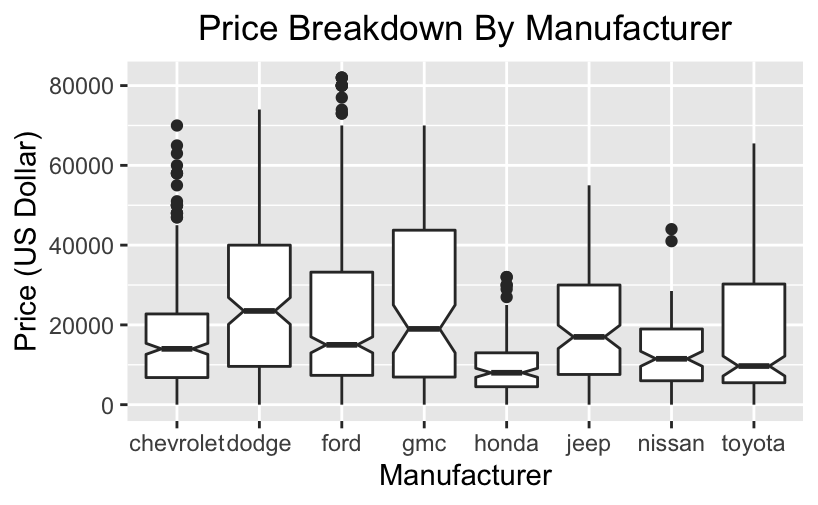

```r
RegressionCars %>%
  ggplot(aes(x = manufacturer, y = price)) +
  geom_boxplot(notch = TRUE, size = 0.5) +
  ylab("Price (US Dollar)") +
  xlab("Manufacturer") +
  labs(title = "Price Breakdown By Manufacturer") +
  theme(plot.title = element_text(hjust = 0.5))
```

**Faceted Scatter Plot w/ Smoother -** This scatter plot shows the trend of price vs. mileage on the car. The drive train of the vehicle is also provided, and the display is broken down by the most popular manufacturers. It is no surprise that there is a negative correlation between price and mileage. However, it appears as if the value of some of the manufacturers vehicles depreciates more / their vehicles value depreciates at a faster rate compared to other manufacturers. For example, nissan and honda vehicles are lower prices overall, but the trend line is almost flat with a slight negative slope. Whereas, gmc and ford vehicles value depreciates significantly as the mileage increases with a much higher negative slope. It is also worth mentioning there is a distinct pattern with price and drive train type. It can be easily seen in chevrolet and toyota vehichles where four wheel drive vehicles are all the most expensive (above the trend line), front wheel drive cars are the cheapest (below the trend line), and rear wheel drive cars are in the middle ground (on / near the trend line).

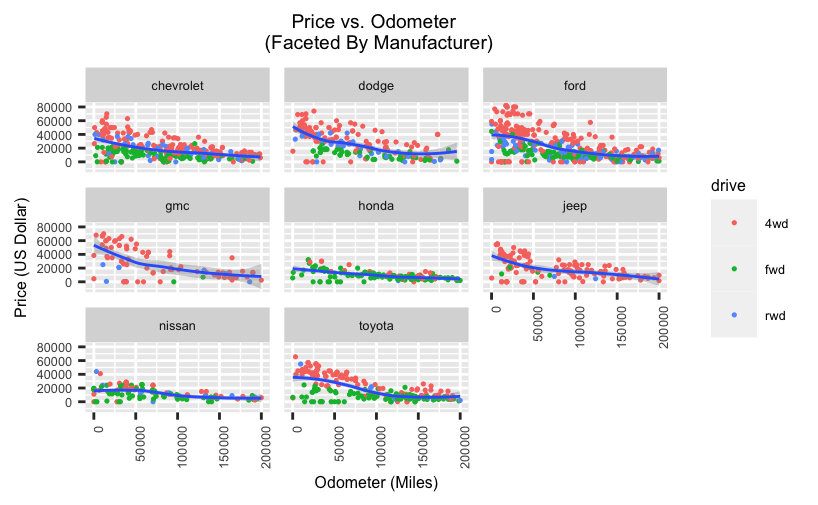

```r
RegressionCars %>%
  filter(price <= 100000, odometer <= 200000) %>%
  ggplot(aes(x = odometer, y = price)) +
  geom_point(aes(colour = drive), size = 0.25) +
  facet_wrap(manufacturer ~ .) +
  geom_smooth(size = 0.5) +
  theme(axis.text.x = element_text(angle = 90, hjust = 1),
text = element_text(size = 6)) +
  ylab("Price (US Dollar)") +
  xlab("Odometer (Miles)") +
  labs(title = "Price vs. Odometer \n (Faceted By Manufacturer)", fill = "Drive Train") +
  theme(plot.title = element_text(hjust = 0.5))
```

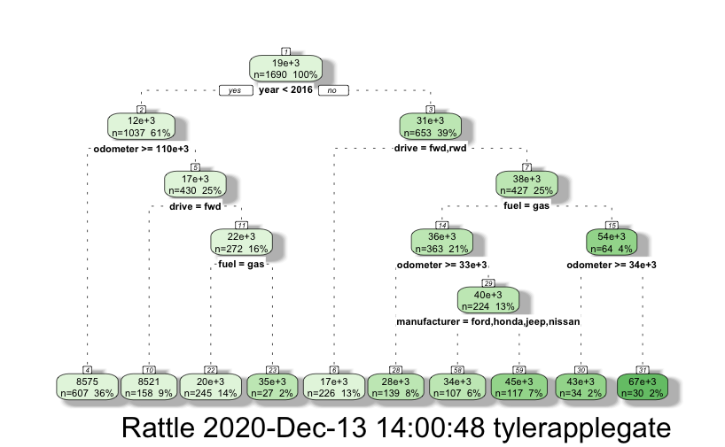

```r
tree1 <- rpart(price ~ year + manufacturer + fuel + odometer + transmission + drive, data = RegressionCars)

fancyRpartPlot(tree1)
```

## Conclusion

After reviewing all of these graphics I feel confident in saying their are certainly aspects of a vehivle that cause it be worth more, or less, at resale.

**Factors Increasing Price -** newer model year, low miles, gas / diesel engine, four wheel drive, manufactured by dodge.

**Factors Decreasing Price -** older model year, high mileage, hybrid / electric powered, front wheel drive, manufactured by honda or nissan.